# DESeq analysis for ZBTB33

This guide follows the [Bioconductor RNA-Seq workflow](http://www.bioconductor.org/help/workflows/rnaseqGene) to find differentially expressed genes in the GSE81784 dataset.

### Load samples and counts

Load the Sample Sheet from 13817R.

```r
samples <- read_tsv("samples.txt")
samples
#  # A tibble: 9 × 4
#         id    name   trt      type
#      <chr>   <chr> <chr>     <chr>
#  1 13817X1  P33sc1    sc scrambled
#  2 13817X2  P33sc2    sc scrambled
#  3 13817X3  P33sc3    sc scrambled
#  4 13817X4 P33si11   si1 targeting
#  5 13817X5 P33si12   si1 targeting
#  6 13817X6 P33si13   si1 targeting
#  7 13817X7 P33si21   si2 targeting
#  8 13817X8 P33si22   si2 targeting
#  9 13817X9 P33si23   si2 targeting
```

Load the nine `featureCount` output files in the `Counts` directory.

```r
counts <- read_featureCounts("Counts/")
counts
#  # A tibble: 58,051 × 10
#              geneid `13817X1` `13817X2` `13817X3` `13817X4` `13817X5` `13817X6` `13817X7` `13817X8` `13817X9`
#               <chr>     <int>     <int>     <int>     <int>     <int>     <int>     <int>     <int>     <int>
#  1  ENSG00000000003      2555      2378      2403      1399      1712      1619      2230      2308      2247
#  2  ENSG00000000005         0         0         0         0         0         0         0         0         0
#  3  ENSG00000000419      2244      2147      2268      1648      1803      1926      1713      1671      1873
#  4  ENSG00000000457       378       367       389       340       438       397       323       319       314
#  5  ENSG00000000460       674       657       705       553       663       684       636       598       650
#  6  ENSG00000000938         2         0         1         0         0         0         0         0         0
#  7  ENSG00000000971       168       196       199       110       125       107       220       234       230
#  8  ENSG00000001036      2641      2388      2551      2460      2676      2428      2258      2247      2317
#  9  ENSG00000001084      2411      2340      2396      2100      2510      2457      2138      2142      2188
#  10 ENSG00000001167      2195      2139      2124      2428      2917      2794      2106      1927      2093
#  # ... with 58,041 more rows
```

Remove 24427 features with zero counts and 16705 features with fewer than 10 reads in any sample to create a final count matrix with 16919 rows.

```r
counts <- filter_counts(counts, n=10)
#  Removed 24427 features with 0 reads
#  Removed 16705 features with <=10 maximum reads
```

### Run DESeq

Combine the counts and samples to create a `DESeqDataSet` object and calculate the regularized log transform (rlog) for sample visualizations.

```r
dds <- deseq_from_tibble(counts, samples, design = ~trt)
#  estimating size factors
#  estimating dispersions
#  gene-wise dispersion estimates
#  mean-dispersion relationship
#  final dispersion estimates
#  fitting model and testing
rld <-  r_log(dds)
```

### PCA plot

Plot the first two principal components using the rlog values from the top 500 variable genes. You can hover over points to view sample names or select a region to zoom into points in this interactive [highchart](http://jkunst.com/highcharter/index.html).

```r
plot_pca(rld, "trt", tooltip=c("id", "name"), width=700)
```

[interactive chart not shown]

### Sample distances

Cluster all the rlog values using the R function `dist` to calculate the Euclidean distance and plot sample distances.

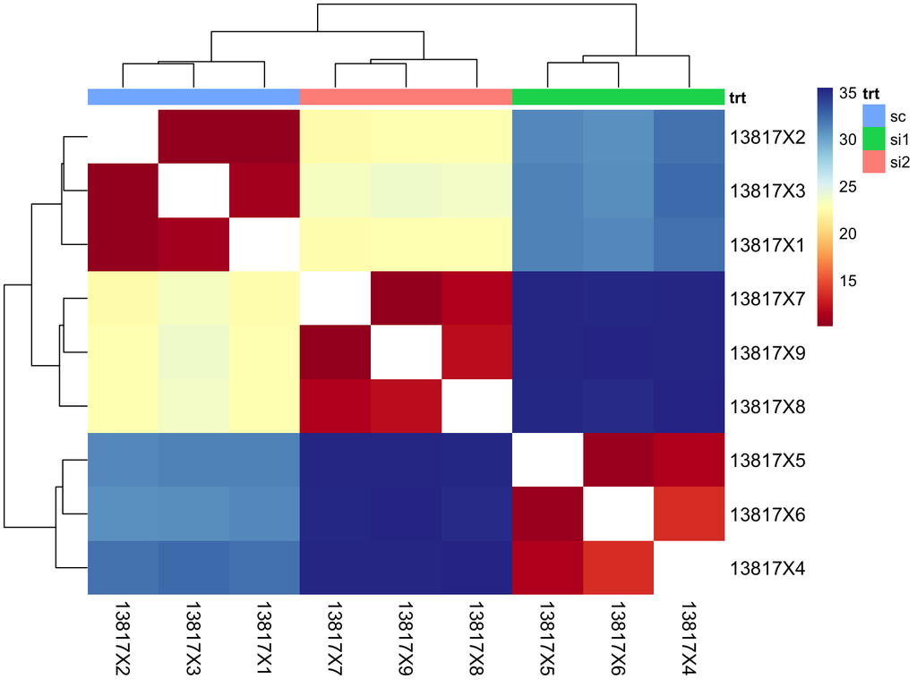

```r
plot_dist(rld, "trt", border=NA)
```

### Gene annotations

Load the human annotations from Ensembl.

```r
#hsa <- read_biomart("human")
data(hsa)
```

### DESeq results

Reorder the factor levels so scrambled control is last and then get the DESeq results using a 5% false discovery rate (FDR).

```r
dds$trt <- factor(dds$trt, levels=c("si1", "si2", "sc"))
res <- results_all(dds, hsa)
#  Using adjusted p-value < 0.05
#  1. si1 vs. si2: 4324 up and 4461 down regulated
#  2. si1 vs. sc:  4059 up and 4168 down regulated
#  3. si2 vs. sc:  3127 up and 2957 down regulated
```

### Comparing targeting siRNAs vs scrambled

Combine the siRNA treatments and compare to scrambled at at 1% FDR.

```r
dds2 <- deseq_from_tibble(counts, samples, design = ~type)
#  estimating size factors
#  estimating dispersions
#  gene-wise dispersion estimates
#  mean-dispersion relationship
#  final dispersion estimates
#  fitting model and testing
rld2 <-  r_log(dds2)
dds2$trt <- factor(dds2$trt, levels=c("targeting", "scrambled"))
res2 <- results_all( dds2, hsa, alpha=0.01)
#  Using adjusted p-value < 0.01
#  1. scrambled vs. targeting: 651 up and 886 down regulated
```

### Save results

Save the DESeq results to a single Excel file in DESeq.xlsx. The function will also output raw counts, rlog values, normalized counts, samples and gene annotations.

```r
write_deseq( dds2, res2, rld2, hsa)
```

### Plot heatmaps

Select the top 40 genes sorted by p-value, join to the rlog matrix and cluster the rlog differences. The values in the heatmap represent the amount a gene deviates in a specific sample from the gene’s average across all samples.

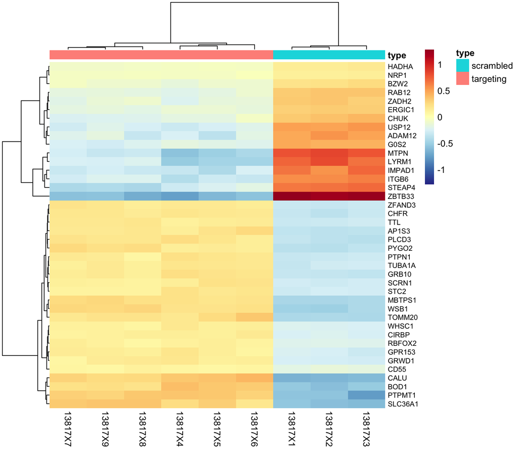

```r
x <- top_counts( res2, rld2)
plot_genes(x, "type", fontsize_row=8)
```